# Bike Trip in San Fransisco and New York

there are two datasets about Bike Trips in San Fransisco and New York in Feb 2019

# distribution of weekday

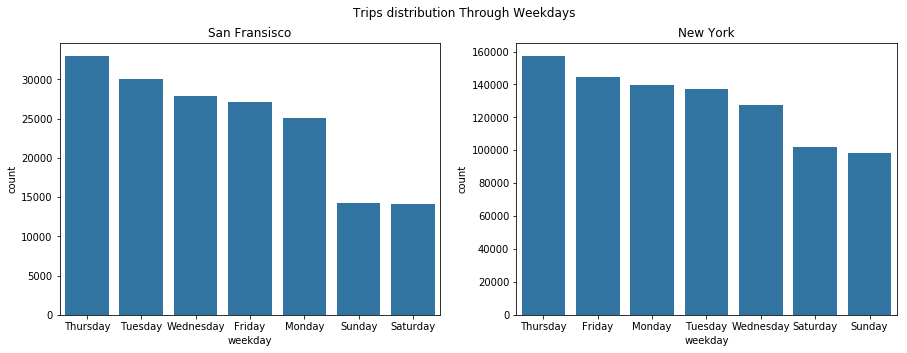

```python
fig, ax =plt.subplots(1,2,sharex="none",figsize=(15,5))
col=sb.color_palette()[0]
order1=["Thursday","Tuesday","Wednesday","Friday","Monday","Sunday","Saturday"]
sb.countplot(result[result["state"]=="San Fransisco"]['weekday'], ax=ax[0],color=col,order=order1)

order2=["Thursday","Friday","Monday","Tuesday","Wednesday","Saturday","Sunday"]
sb.countplot(result[result["state"]=="New York"]['weekday'], ax=ax[1],color=col,order=order2)
fig.suptitle('Trips distribution Through Weekdays')

ax[0].set_title("San Fransisco")
ax[1].set_title("New York");
```

As we can See in the 2 bar chart :

```
for San fransisco the ascending order of most trips are  Thursday,Tuseday,Wednesday,Friday,Monday,Sunday,Saturday

for New York the ascending order of most trips are  Thursday,Friday,Monday,Tuseday,Wednesday,Saturday,Sunday
```

# distribution of hour through day

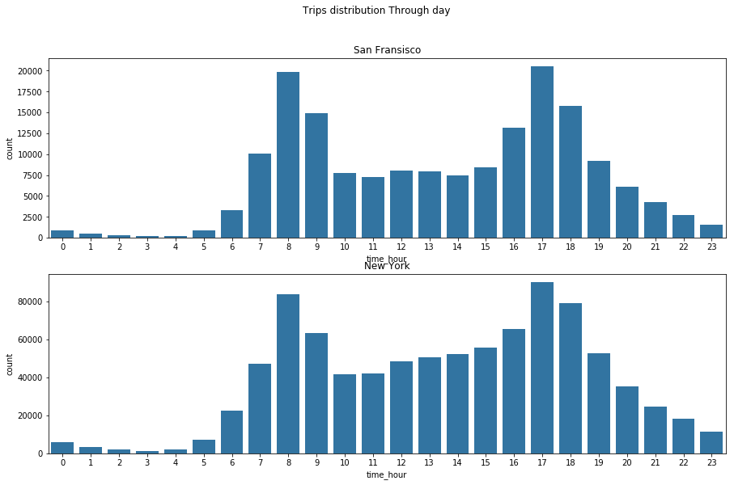

```python
fig, ax =plt.subplots(2,1,sharex="none",figsize=(15,9));col=sb.color_palette()[0]
sb.countplot(result[result["state"]=="San Fransisco"]['time_hour'], ax=ax[0],color=col);
sb.countplot(result[result["state"]=="New York"]['time_hour'], ax=ax[1],color=col)
fig.suptitle('Trips distribution Through day');ax[0].set_title("San Fransisco");ax[1].set_title("New York");
```

for San Fransisco and New York Most trips in term of time of the day at hour (8 and 17)

for San Fransisco and New York Least trips through the day at hour (2,3,4)

# distribution of member_birth_year

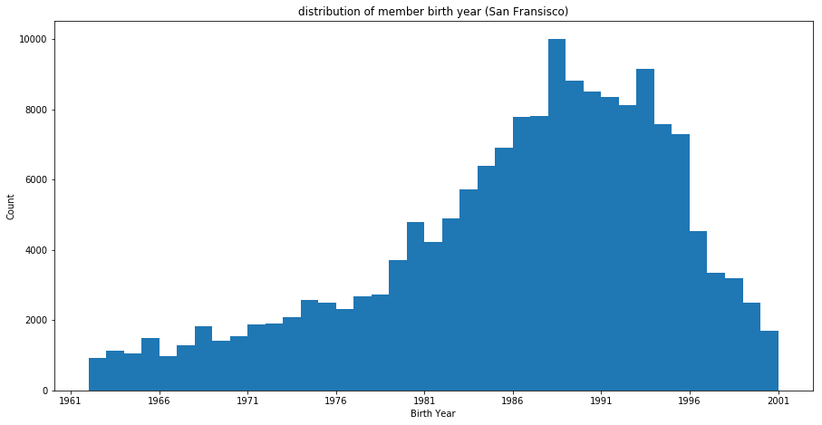

```python
plt.figure(figsize=(15,7.5))
bins1=np.arange(df_san_frans["member_birth_year"].min(),df_san_frans["member_birth_year"].max()+1,1)
plt.hist(data= df_san_frans, x="member_birth_year",bins=bins1);
plt.title("distribution of member birth year (San Fransisco)");
plt.xticks(np.arange(1961,2001+5,5))
plt.xlabel("Birth Year")
plt.ylabel("Count");
```

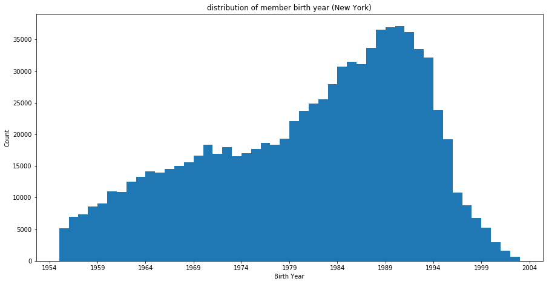

```python
plt.figure(figsize=(15,7.5))
bins2=np.arange(df_new_york["member_birth_year"].min(),df_new_york["member_birth_year"].max()+1,1)
plt.hist(data= df_new_york, x="member_birth_year",bins=bins2);
plt.title("distribution of member birth year (New York)");
plt.xticks(np.arange(1954,2003+5,5))

plt.xlabel("Birth Year")
plt.ylabel("Count");
```

For San Fransisco the distribution has more slope than New york, San Fransisco has peak between 1988 -1994 and there is a steep drop after 1996.

For New York the distribution has peak between years (1986 and 1993) and there are a steep drop after 1994

# distribution of duration_Sec

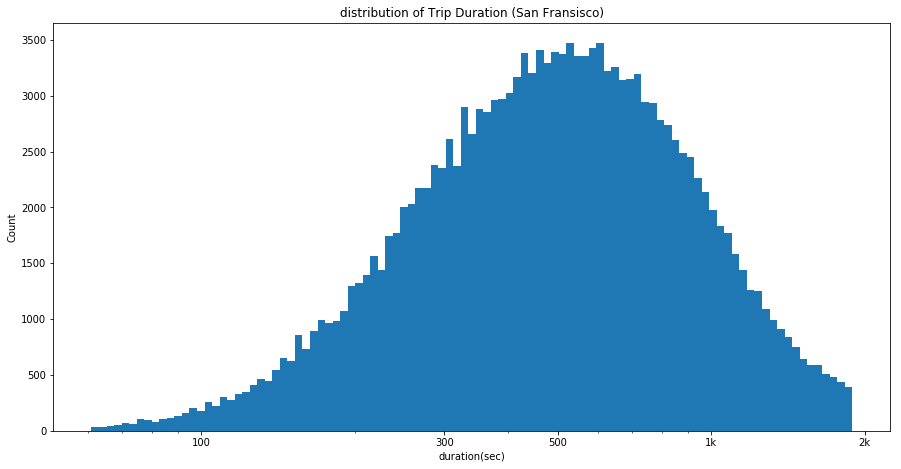

```python
# there's a long tail in the distribution, so let's put it on a log scale instead
plt.figure(figsize=(15,7.5))
log_bsize=0.01477
bin1=10** np.arange(np.log10(df_san_frans["duration_sec"].min()),np.log10(df_san_frans["duration_sec"].max())+log_bsize,log_bsize)
plt.hist(data= df_san_frans, x="duration_sec",bins=bin1);
plt.xscale('log')
plt.xticks([100,300,500, 1e3, 2e3], [100,300,500, '1k', '2k'])
plt.title("distribution of Trip Duration (San Fransisco)");
plt.xlabel("duration(sec)")
plt.ylabel("Count");
```

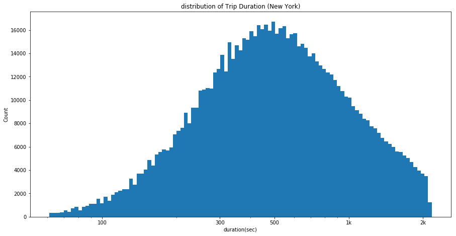

```python
plt.figure(figsize=(15,7.5))
log_bsize =0.01477
bin1=10** np.arange(np.log10(df_new_york["duration_sec"].min()),np.log10(df_new_york["duration_sec"].max())+log_bsize,log_bsize)
plt.hist(data= df_new_york, x="duration_sec",bins=bin1);
plt.xscale('log')
plt.xticks([100,300,500, 1e3, 2e3], [100,300,500, '1k', '2k'])
plt.title("distribution of Trip Duration (New York)");
plt.xlabel("duration(sec)")
plt.ylabel("Count");
```

The distribution of trip duration for san fransisco has peak values in range of (400-700)sec and the curve has more steep slope than new york. New york has peak values in range of(400-600) but the slope or drop of the curve on the two sides is lighter than san fransisco

# distribution of user_type

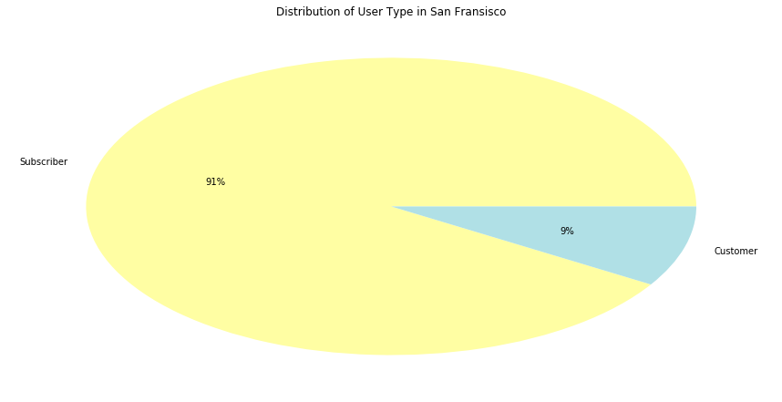

```python
IAP = df_san_frans['user_type'].value_counts().to_frame().T
plt.figure(figsize=(15,7.5))
colors = sb.color_palette('pastel')[4:6]
mylabels = ["Subscriber", "Customer"]
plt.pie(IAP.iloc[0],labels = mylabels,colors=colors,startangle = 360,autopct='%.0f%%');
plt.title("Distribution of User Type in San Fransisco");
```

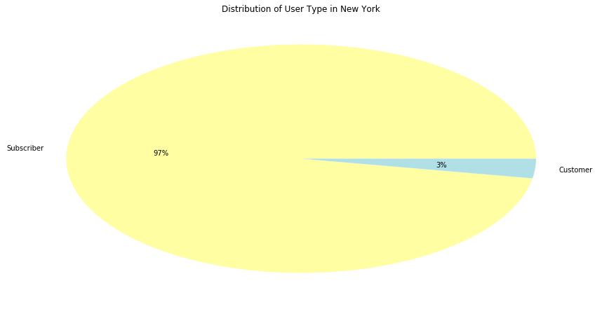

```python
AP = df_new_york['user_type'].value_counts().to_frame().T
plt.figure(figsize=(15,7.5))
colors = sb.color_palette('pastel')[4:6]
mylabels = ["Subscriber", "Customer"]
plt.pie(AP.iloc[0],labels = mylabels,colors=colors,startangle = 360,autopct='%.0f%%');
plt.title("Distribution of User Type in New York");
```

For San Fransisco the usere are 91% Subscriber and 9% Customer For New York the usere are 97% Subscriber and 3% Customer

# distribution of member_gender

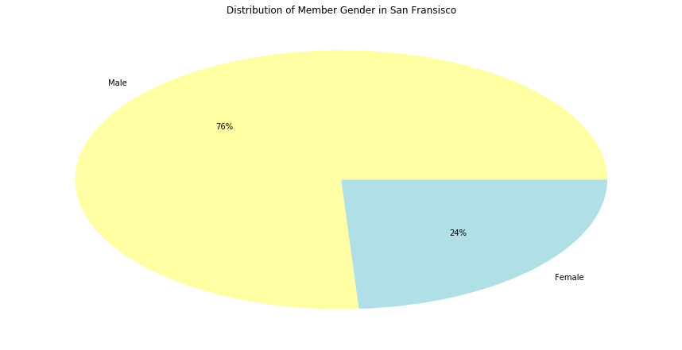

```python
I = df_san_frans['member_gender'].value_counts().to_frame().T
plt.figure(figsize=(15,7.5))
colors = sb.color_palette('pastel')[4:6]
mylabels = ["Male", "Female"]
plt.pie(I.iloc[0],labels = mylabels,colors=colors,startangle = 360,autopct='%.0f%%');
plt.title("Distribution of Member Gender in San Fransisco");
```

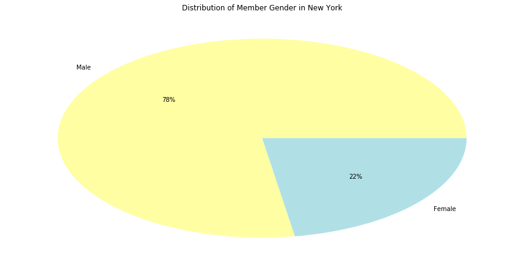

```python
A = df_new_york['member_gender'].value_counts().to_frame().T
plt.figure(figsize=(15,7.5))
colors = sb.color_palette('pastel')[4:6]
mylabels = ["Male", "Female"]
plt.pie(A.iloc[0],labels = mylabels,colors=colors,startangle = 360,autopct='%.0f%%');
plt.title("Distribution of Member Gender in New York");
```

For San Fransisco the usere are 76% Male and 24% Female For New York the usere are 78% Male and 22% Female

# time_hour VS duration_sec

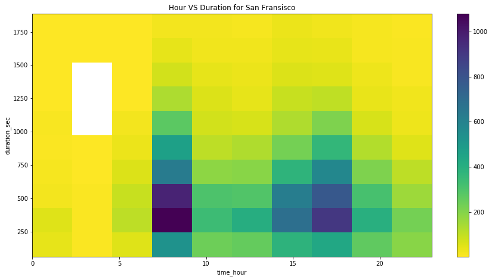

```python
samples1 =df_san_frans.sample(frac=0.1)
plt.figure(figsize=(15,7.5))
plt.hist2d(data=samples1,x="time_hour",y="duration_sec",cmin=0.5,cmap='viridis_r')
plt.colorbar()
plt.title("Hour VS Duration for San Fransisco")
plt.xlabel("time_hour")
plt.ylabel("duration_sec");
```

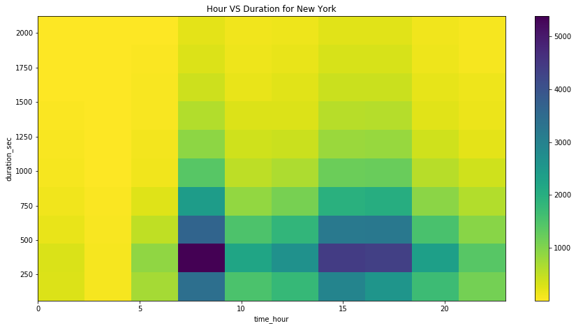

```python
samples2 =df_new_york.sample(frac=0.1)
plt.figure(figsize=(15,7.5))
plt.hist2d(data=samples2,x="time_hour",y="duration_sec",cmin=0.5,cmap='viridis_r')
plt.colorbar()
plt.title("Hour VS Duration for New York")
plt.xlabel("time_hour")
plt.ylabel("duration_sec");
```

as we can see in the two charts for San Fransisco and New york the most frequent trips occur in morning at 7 to 9 and 16 to 18 and their duration are mostly near to 500 sec

# Relation between Weekdays VS Duration of trips(sec)

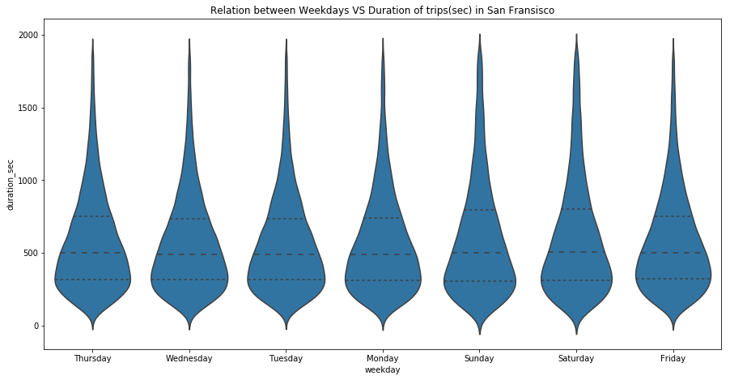

```python
plt.figure(figsize=(15,7.5));
col=sb.color_palette()[0]
sb.violinplot(x="weekday", y="duration_sec", data=df_san_frans,color=col,inner='quartile')
plt.title("Relation between Weekdays VS Duration of trips(sec) in San Fransisco");
```

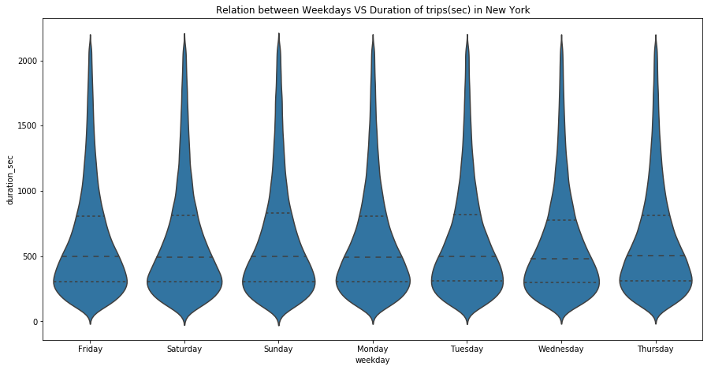

```python
plt.figure(figsize=(15,7.5));
col=sb.color_palette()[0]
sb.violinplot(x="weekday", y="duration_sec", data=df_new_york,color=col,inner='quartile')
plt.title("Relation between Weekdays VS Duration of trips(sec) in New York");
```

# Relation between trip duration and weekday for each user_type

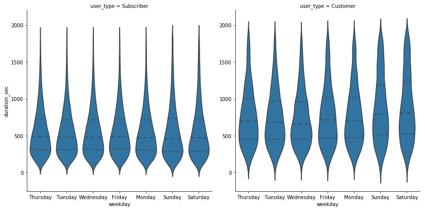

```python
g = sb.FacetGrid(data = df_san_frans, col = 'user_type', size = 6)
order1=["Thursday","Tuesday","Wednesday","Friday","Monday","Sunday","Saturday"]
g.map(sb.violinplot, 'weekday', 'duration_sec',inner='quartile',order=order1);
```

For San Fransisco For subscribers 1st quartile at 300 sec , 2nd quartile at 500 sec , 3 quartile at 750 sec and the most trips takes nearly 300 sec

For customers 1st quartile at 450 sec, 2nd quartile at 700 sec and 3rd quartile at 1000 sec and the most trips takes nearly 500 sec

in general the customer trips takes more time than subscriber trips

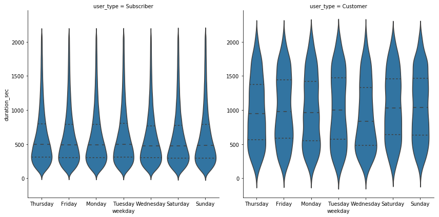

```python
g = sb.FacetGrid(data = df_new_york, col = 'user_type', size = 6)
order2=["Thursday","Friday","Monday","Tuesday","Wednesday","Saturday","Sunday"]
g.map(sb.violinplot, 'weekday', 'duration_sec',inner='quartile',order=order2);
```

in New York For subscribers 1st quartile at 300 sec , 2nd quartile at 500 sec , 3 quartile at 800 sec and the most trips takes nearly 300 sec

in general the customer trips takes more time than subscriber trips